# PREDICCIÓN DE LA PATOGENICIDAD DE LAS MUTACIONES MISSENSE DEL GEN TP53

Análisis descriptivo

Peter Olejua Maestría en Bioestadística Departamento de Epidemiología Clínica y Bioestadística olejua.peter@javeriana.edu.co

2019-10-31

# 1 Librerías

```r
library(knitr)
library(readr)
library(dplyr) # Manipulate data
library(tidyr) # Manipulate data
library(splitstackshape) # split variables
library(reshape2)
library(ggplot2)
library(GGally)
library(papeR) # sumarize table
library(corrplot)
```

# 2 Load the data

```r
mutations <- read.delim("../0_get_data/0_RawData/UMD/UMD_mutations_US.tsv", stringsAsFactors=FALSE)
misMut <- filter(mutations, startsWith(Variant_Classification,"Missense") & Variant_Type=="SNP")

data <- readRDS("../0_get_data/1_processed_data/data.rds")

# glimpse(data)
```

# 3 UMD missense mutations

```r
dim(misMut)
```

```
[1] 57885   133
```

```r
table(misMut$Pathogenicity)
```

```
             Benign   Likely Pathogenic          Pathogenic
                 80                5871               38145
Possibly pathogenic                 VUS
               9979                3810
```

# 4 Resumen de variantes únicas

```r
data %>%
  select(SIFT_score:bStatistic) %>%
  dim()
```

```
[1] 1764   25
```

```r
data %>%
  select(SIFT_score:REVEL_score) %>%
  data.frame() %>%
  summarize() %>%
  kable()
```

|  | N | Missing |  | Mean | SD |  | Min | Q1 | Median | Q3 | Max |
| --- | --- | --- | --- | --- | --- | --- | --- | --- | --- | --- | --- |
| SIFT_score | 1751 | 13 |  | 0.11 | 0.21 |  | 0.00 | 0.00 | 0.01 | 0.12 | 1.00 |
| FATHMM_score | 1751 | 13 |  | -6.36 | 1.15 |  | -10.62 | -7.05 | -6.69 | -5.56 | -2.04 |
| PROVEAN_score | 1751 | 13 |  | -3.07 | 2.89 |  | -11.72 | -5.11 | -2.62 | -0.66 | 4.49 |
| VEST4_score | 1751 | 13 |  | 0.55 | 0.28 |  | 0.05 | 0.30 | 0.56 | 0.82 | 1.00 |
| Polyphen2_HDIV_score | 1751 | 13 |  | 0.59 | 0.45 |  | 0.00 | 0.02 | 0.87 | 1.00 | 1.00 |
| Polyphen2_HVAR_score | 1751 | 13 |  | 0.58 | 0.43 |  | 0.00 | 0.06 | 0.77 | 0.99 | 1.00 |
| MutationAssessor_score | 1747 | 17 |  | 2.20 | 0.96 |  | -3.29 | 1.67 | 2.36 | 2.98 | 3.50 |
| LRT_score | 1741 | 23 |  | 0.09 | 0.19 |  | 0.00 | 0.00 | 0.00 | 0.03 | 0.92 |
| fathmm.MKL_coding_score | 1764 | 0 |  | 0.72 | 0.36 |  | 0.00 | 0.40 | 0.95 | 0.99 | 1.00 |
| fathmm.XF_coding_score | 1764 | 0 |  | 0.55 | 0.33 |  | 0.02 | 0.21 | 0.57 | 0.91 | 0.99 |
| MutPred_score | 1714 | 50 |  | 0.62 | 0.27 |  | 0.07 | 0.38 | 0.68 | 0.86 | 0.99 |
| PrimateAI_score | 1687 | 77 |  | 0.51 | 0.15 |  | 0.20 | 0.39 | 0.50 | 0.63 | 0.90 |
| integrated_fitCons_score | 1764 | 0 |  | 0.72 | 0.01 |  | 0.56 | 0.72 | 0.72 | 0.72 | 0.73 |
| GM12878_fitCons_score | 1764 | 0 |  | 0.70 | 0.01 |  | 0.58 | 0.70 | 0.70 | 0.70 | 0.70 |
| H1.hESC_fitCons_score | 1764 | 0 |  | 0.71 | 0.02 |  | 0.60 | 0.70 | 0.70 | 0.72 | 0.78 |
| HUVEC_fitCons_score | 1764 | 0 |  | 0.73 | 0.03 |  | 0.32 | 0.74 | 0.74 | 0.74 | 0.74 |
| GERP.._RS | 1764 | 0 |  | 2.65 | 3.13 |  | -11.00 | 1.40 | 3.65 | 4.72 | 5.59 |
| phyloP100way_vertebrate | 1764 | 0 |  | 3.54 | 3.59 |  | -4.88 | 0.44 | 2.51 | 7.48 | 10.00 |
| phyloP30way_mammalian | 1764 | 0 |  | 0.70 | 0.68 |  | -3.46 | 0.18 | 1.03 | 1.17 | 1.31 |
| phyloP17way_primate | 1764 | 0 |  | 0.48 | 0.42 |  | -2.96 | 0.60 | 0.66 | 0.68 | 0.76 |
| phastCons100way_vertebrate | 1764 | 0 |  | 0.66 | 0.45 |  | 0.00 | 0.02 | 1.00 | 1.00 | 1.00 |
| phastCons30way_mammalian | 1764 | 0 |  | 0.63 | 0.42 |  | 0.00 | 0.10 | 0.90 | 0.99 | 1.00 |
| phastCons17way_primate | 1764 | 0 |  | 0.72 | 0.35 |  | 0.00 | 0.55 | 0.91 | 0.99 | 1.00 |
| X29way_logOdds | 1757 | 7 |  | 9.80 | 4.34 |  | 0.06 | 6.46 | 9.98 | 13.06 | 20.17 |
| bStatistic | 1764 | 0 |  | 434.92 | 4.95 |  | 432.00 | 433.00 | 434.00 | 434.00 | 453.00 |
| REVEL_score | 1764 | 0 |  | 0.66 | 0.23 |  | 0.10 | 0.46 | 0.69 | 0.88 | 0.98 |

## 4.1 Por patogenicidad

```r
data %>%
  select(Pathogenicity) %>%
  mutate(Pathogenicity = ordered(x = Pathogenicity,
                                 levels=c("Benign",
                                          "Possibly pathogenic",
                                          "Likely Pathogenic",
                                          "Pathogenic",
                                          "VUS")
                                 )) %>%
  data.frame() %>%
  summarize(type = "fac") %>%
  kable()
```

|  | Level |  | N | % |
| --- | --- | --- | --- | --- |
| Pathogenicity | Benign |  | 16 | 0.9 |
|  | Possibly pathogenic |  | 465 | 26.4 |
|  | Likely Pathogenic |  | 90 | 5.1 |
|  | Pathogenic |  | 102 | 5.8 |
|  | VUS |  | 1091 | 61.8 |

```r
data %>%
  select(SIFT_score:Pathogenicity) %>%
  mutate(Pathogenicity = ordered(x = Pathogenicity,
                                 levels=c("Benign",
                                          "Possibly pathogenic",
                                          "Likely Pathogenic",
                                          "Pathogenic",
                                          "VUS"),
                                 labels=(c("Ben","Pos","Lik","Pat","VUS"))
                                 )) %>%
  data.frame() %>%
  summarize(group = "Pathogenicity", test=F) %>%
  kable(row.names = F)
```

|  | Pathogenicity |  | N | Missing |  | Mean | SD |  | Min | Q1 | Median | Q3 | Max |
| --- | --- | --- | --- | --- | --- | --- | --- | --- | --- | --- | --- | --- | --- |
| SIFT_score | Ben |  | 3 | 13 |  | 0.35 | 0.25 |  | 0.16 | 0.21 | 0.26 | 0.45 | 0.64 |
|  | Pos |  | 465 | 0 |  | 0.02 | 0.06 |  | 0.00 | 0.00 | 0.00 | 0.00 | 0.51 |
|  | Lik |  | 90 | 0 |  | 0.01 | 0.01 |  | 0.00 | 0.00 | 0.00 | 0.00 | 0.07 |
|  | Pat |  | 102 | 0 |  | 0.00 | 0.01 |  | 0.00 | 0.00 | 0.00 | 0.00 | 0.13 |
|  | VUS |  | 1091 | 0 |  | 0.17 | 0.24 |  | 0.00 | 0.00 | 0.06 | 0.24 | 1.00 |
| FATHMM_score | Ben |  | 3 | 13 |  | -5.46 | 0.04 |  | -5.51 | -5.48 | -5.45 | -5.44 | -5.43 |
|  | Pos |  | 465 | 0 |  | -6.90 | 0.93 |  | -10.61 | -7.27 | -6.97 | -6.72 | -3.17 |
|  | Lik |  | 90 | 0 |  | -7.29 | 0.97 |  | -10.62 | -7.42 | -7.29 | -6.99 | -3.15 |
|  | Pat |  | 102 | 0 |  | -7.34 | 0.77 |  | -10.62 | -7.50 | -7.30 | -7.03 | -3.64 |
|  | VUS |  | 1091 | 0 |  | -5.96 | 1.09 |  | -9.00 | -6.73 | -6.31 | -5.49 | -2.04 |
| PROVEAN_score | Ben |  | 3 | 13 |  | 0.02 | 0.36 |  | -0.23 | -0.18 | -0.14 | 0.15 | 0.44 |
|  | Pos |  | 465 | 0 |  | -4.89 | 2.55 |  | -11.71 | -6.55 | -4.88 | -2.89 | 1.18 |
|  | Lik |  | 90 | 0 |  | -6.12 | 2.56 |  | -11.72 | -7.78 | -6.21 | -3.89 | -0.57 |
|  | Pat |  | 102 | 0 |  | -6.29 | 2.58 |  | -10.74 | -8.48 | -6.17 | -3.92 | -1.66 |
|  | VUS |  | 1091 | 0 |  | -1.75 | 2.15 |  | -9.57 | -3.03 | -1.17 | -0.19 | 4.49 |
| VEST4_score | Ben |  | 3 | 13 |  | 0.11 | 0.04 |  | 0.08 | 0.08 | 0.08 | 0.12 | 0.16 |
|  | Pos |  | 465 | 0 |  | 0.75 | 0.19 |  | 0.16 | 0.65 | 0.82 | 0.90 | 1.00 |
|  | Lik |  | 90 | 0 |  | 0.87 | 0.12 |  | 0.46 | 0.81 | 0.92 | 0.96 | 1.00 |
|  | Pat |  | 102 | 0 |  | 0.90 | 0.08 |  | 0.60 | 0.87 | 0.93 | 0.96 | 0.99 |
|  | VUS |  | 1091 | 0 |  | 0.41 | 0.22 |  | 0.05 | 0.22 | 0.36 | 0.57 | 0.96 |
| Polyphen2_HDIV_score | Ben |  | 3 | 13 |  | 0.03 | 0.05 |  | 0.00 | 0.00 | 0.01 | 0.05 | 0.08 |
|  | Pos |  | 465 | 0 |  | 0.84 | 0.33 |  | 0.00 | 0.95 | 1.00 | 1.00 | 1.00 |
|  | Lik |  | 90 | 0 |  | 0.97 | 0.09 |  | 0.30 | 1.00 | 1.00 | 1.00 | 1.00 |
|  | Pat |  | 102 | 0 |  | 0.94 | 0.18 |  | 0.03 | 0.99 | 1.00 | 1.00 | 1.00 |
|  | VUS |  | 1091 | 0 |  | 0.42 | 0.44 |  | 0.00 | 0.00 | 0.16 | 0.96 | 1.00 |
| Polyphen2_HVAR_score | Ben |  | 3 | 13 |  | 0.02 | 0.02 |  | 0.00 | 0.00 | 0.00 | 0.02 | 0.04 |
|  | Pos |  | 465 | 0 |  | 0.84 | 0.30 |  | 0.00 | 0.84 | 0.99 | 1.00 | 1.00 |
|  | Lik |  | 90 | 0 |  | 0.96 | 0.12 |  | 0.04 | 0.96 | 1.00 | 1.00 | 1.00 |
|  | Pat |  | 102 | 0 |  | 0.92 | 0.19 |  | 0.09 | 0.98 | 1.00 | 1.00 | 1.00 |
|  | VUS |  | 1091 | 0 |  | 0.40 | 0.41 |  | 0.00 | 0.01 | 0.19 | 0.88 | 1.00 |

[output cut: 100 more lines]

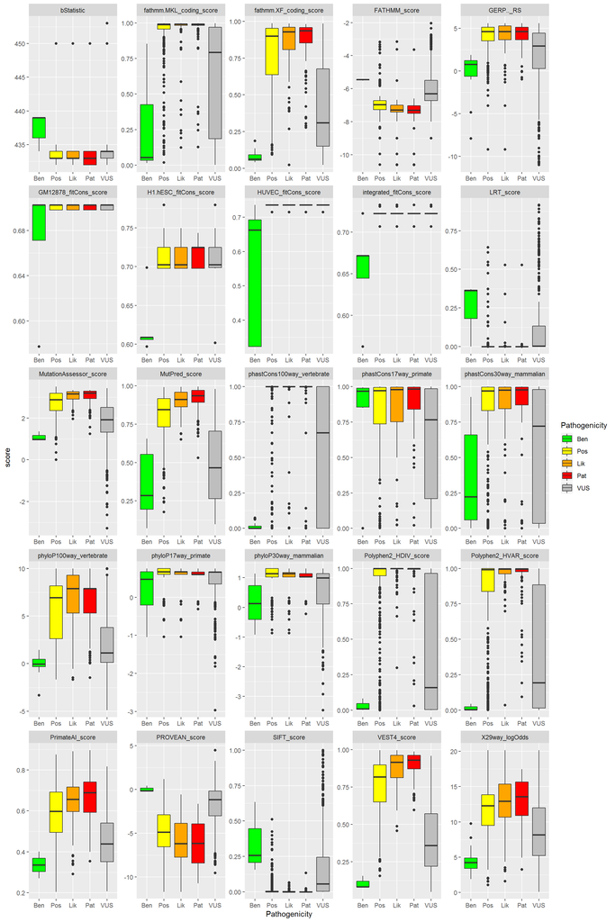

```r
data %>%
  select(cDNA_variant, SIFT_score:bStatistic,Pathogenicity) %>%
  gather(variable, score, SIFT_score:bStatistic) %>%
  mutate(Pathogenicity = ordered(x = Pathogenicity,
                                 levels=c("Benign",
                                          "Possibly pathogenic",
                                          "Likely Pathogenic",
                                          "Pathogenic",
                                          "VUS"),
                                 labels=(c("Ben","Pos","Lik","Pat","VUS"))
                                 )) %>%
  ggplot(aes(Pathogenicity, score, fill=Pathogenicity))+
  facet_wrap(. ~ variable, scales = "free", ncol = 5)+
  geom_boxplot()+
  scale_fill_manual(values=c("green", "yellow", "orange", "red", "gray"))
```

# 5 Casos completos

```r
data %>%
  select(SIFT_score:bStatistic) %>%
  drop_na(SIFT_score:bStatistic) %>%
  dim()
```

```
[1] 1626   25
```

```r
data %>%
  select(SIFT_score:Pathogenicity) %>%
  drop_na(SIFT_score:bStatistic) %>%
  mutate(Pathogenicity = ordered(x = Pathogenicity,
                                 levels=c("Benign",
                                          "Possibly pathogenic",
                                          "Likely Pathogenic",
                                          "Pathogenic",
                                          "VUS")
                                 )) %>%
  data.frame() %>%
  summarize(type = "fac") %>%
  kable()
```

|  | Level |  | N | % |
| --- | --- | --- | --- | --- |
| Pathogenicity | Benign |  | 0 | 0.0 |
|  | Possibly pathogenic |  | 447 | 27.5 |
|  | Likely Pathogenic |  | 88 | 5.4 |
|  | Pathogenic |  | 97 | 6.0 |
|  | VUS |  | 994 | 61.1 |

# 6 Pocentaje total de missings (sin VUS)

```r
data %>%
  filter(Pathogenicity != "VUS") %>%
  select(SIFT_score:bStatistic) %>%
  ( function(x) sum(is.na(x))/prod(dim(x)) * 100) %>%
  round(2) %>%
  paste("%")
```

```
[1] "0.89 %"
```

# 7 Correlación

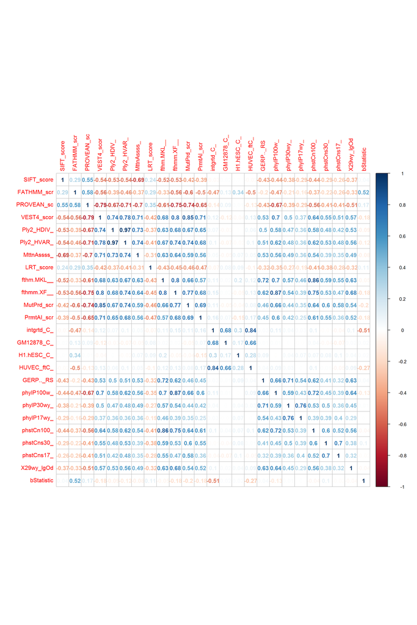

```r
data %>%
  select(SIFT_score:bStatistic) %>%
  cor(use = "pairwise") -> M

colnames(M) <- abbreviate(colnames(M),minlength = 10)
rownames(M) <- abbreviate(rownames(M),minlength = 10)

corrplot(M,method="number")
```

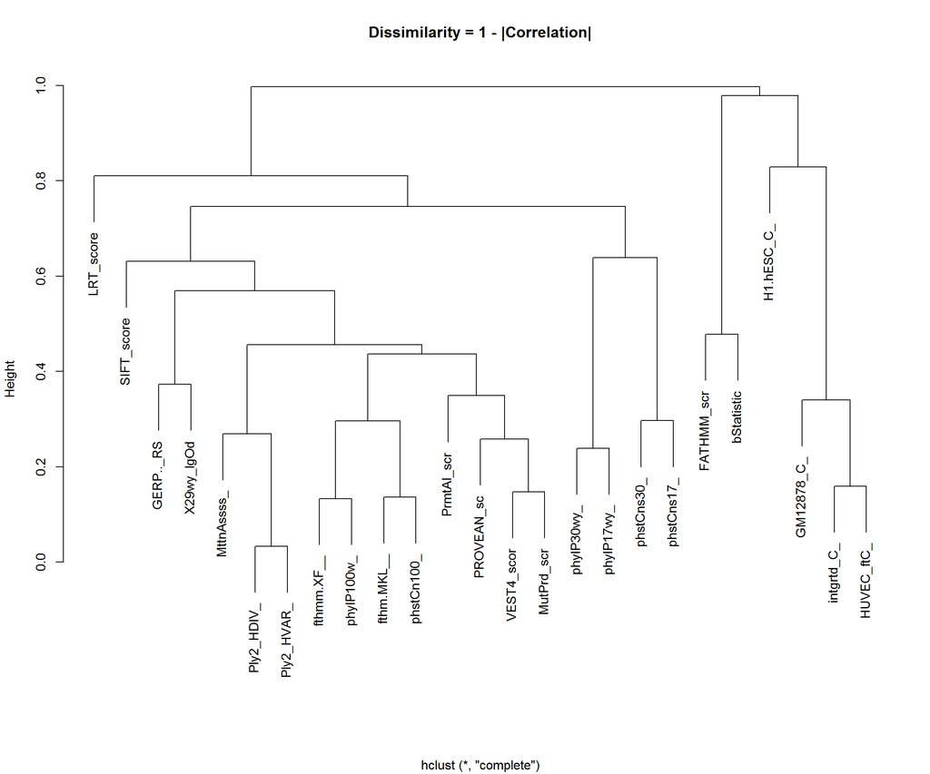

```r
dissimilarity <- 1 - abs(M)
distance <- as.dist(dissimilarity)

plot(hclust(distance), method = "single",
     main="Dissimilarity = 1 - |Correlation|", xlab="")
```

# 8 Norma L2 como en Tang

```r
M2 <- M
diag(M2) <- 0
M2[lower.tri(M2)] <- 0
View(M2)

norm(M2, type = "1")
```

```
[1] 9.619209
```

```r
M2 %>%
  apply(2, function(x) sqrt(sum(x^2))) %>%
  sum()/ choose(ncol(M),2)
```

```
[1] 0.1168489
```

# 9 log-information

```r
data %>%
  filter(Pathogenicity != "VUS") %>%
  select(SIFT_score:bStatistic) %>%
  (function(x) nrow(x)/ncol(x)) %>%
  log10()
```

```
[1] 1.430075
```

# 10 Revel score

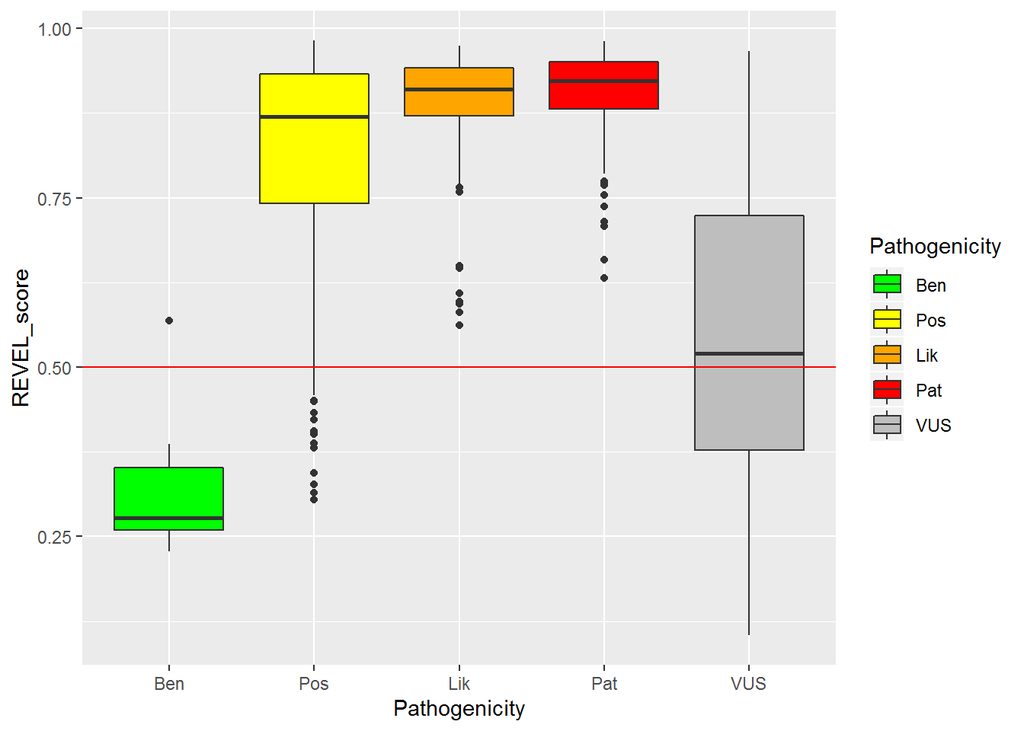

```r
data %>%
  mutate(Pathogenicity = ordered(x = Pathogenicity,
                                 levels=c("Benign",
                                          "Possibly pathogenic",
                                          "Likely Pathogenic",
                                          "Pathogenic",
                                          "VUS"),
                                 labels=(c("Ben","Pos","Lik","Pat","VUS"))
                                 )) %>%
  ggplot(aes(Pathogenicity, REVEL_score,fill=Pathogenicity))+
  geom_boxplot()+
  scale_fill_manual(values=c("green", "yellow", "orange", "red", "gray"))+
  geom_hline(yintercept = 0.5, colour="red")
```

# 11 IARC

```r
iarc_germ <- read.delim("IARC/germinales/datasets/germlineMutationDataIARC TP53 Database, R19.txt")

iarc_som <- read.delim("IARC/somaticas/datasets/somaticMutationDataIARC TP53 Database, R19.txt")

iarc_gene_var <- read.delim("IARC-TP53/datasets/geneVariationIARC TP53 Database, R19.txt")
```

## 11.1 Germinales

- Total

```r
iarc_germ %>%
  pull(c_description) %>%
  length()
```

```
[1] 3842
```

```r
iarc_germ %>%
  pull(Effect) %>%
  table()
```

```
.
       FS  intronic large del  missense  nonsense     other    silent
      273        22        66      2741       295        88        11
   splice
      338
```

- Únicas

```r
iarc_germ %>%
  pull(c_description) %>%
  unique() %>%
  length()
```

```
[1] 457
```

```r
iarc_germ %>%
  select(c_description,Effect) %>%
  unique() %>%
  pull(Effect) %>%
  table()
```

```
.
       FS  intronic large del  missense  nonsense     other    silent
       74         8         9       266        30        20         7
   splice
       41
```

- Germinales missense únicas

```r
iarc_germ %>%
  filter(Effect == "missense") %>%
  pull(c_description) %>%
  unique() %>%
  length()
```

```
[1] 266
```

## 11.2 Somáticas

- Total

```r
iarc_som %>%
  pull(c_description) %>%
  length()
```

```
[1] 29894
```

```r
iarc_som %>%
  pull(Effect) %>%
  table()
```

```
.
       FS  intronic large del  missense  nonsense     other    silent
     2684       218        49     21808      2409       658      1241
   splice
      700
```

- Únicas

```r
iarc_som %>%
  pull(c_description) %>%
  unique() %>%
  length()
```

```
[1] 4527
```

```r
iarc_som %>%
  select(c_description,Effect) %>%
  unique() %>%
  pull(Effect) %>%
  table()
```

```
.
       FS  intronic large del  missense  nonsense     other    silent
     1529       166         6      1631       128       448       380
   splice
      155
```

- missense únicas

```r
iarc_som %>%
  filter(Effect == "missense") %>%
  pull(c_description) %>%
  unique() %>%
  length()
```

```
[1] 1631
```

## 11.3 Unión

unicas unidas:

```r
iarc_germ %>%
  filter(
    Effect == "missense"
  ) %>%
  select(g_description) %>%
  rbind(
    iarc_som %>%
      filter(
        Effect == "missense"
      ) %>%
      select(g_description)
  ) %>%
  n_distinct()
```

```
[1] 1652
```

Cuántas están en gen_var

```r
iarc_germ %>%
  filter(
    Effect == "missense"
  ) %>%
  select(g_description) %>%
  rbind(
    iarc_som %>%
      filter(
        Effect == "missense"
      ) %>%
      select(g_description)
  ) %>%
  unique() %>%
  pull(g_description) %in% iarc_gene_var$g_description %>% sum()
```

```
[1] 1651
```

Cuántas están en UMD

```r
iarc_germ %>%
  filter(
    Effect == "missense"
  ) %>%
  select(g_description) %>%
  rbind(
    iarc_som %>%
      filter(
        Effect == "missense"
      ) %>%
      select(g_description)
  ) %>%
  unique() %>%
  pull(g_description) %in% gsub("NC_000017.10:","",data$HG19_variant) %>% sum()
```

```
[1] 1425
```

```r
iarc_germ %>%
  filter(Effect == "missense") %>%
  select(
    g_description,
    TransactivationClass
    ) %>%
  unique() -> iarc_germ_mis

iarc_som %>%
  filter(Effect == "missense") %>%
  select(g_description, TransactivationClass) %>%
  unique() -> iarc_som_mis

iarc_germ_mis %>%
  rbind(iarc_som_mis) %>%
  unique() %>%
  mutate(
    TransactivationClass = factor(
      TransactivationClass,
      levels = c("supertrans",
          "functional",
          "partially functional",
          "non-functional"
        ),
      ordered = T
    )
    ) -> iarc_missense

summary(iarc_missense)
```

```
      g_description            TransactivationClass
 g.?         :   2   supertrans          : 54
 g.7572938C>T:   1   functional          :563
 g.7572946T>G:   1   partially functional:389
 g.7572958A>G:   1   non-functional      :529
 g.7572973C>T:   1   NA's                :118
 g.7573931A>C:   1
 (Other)     :1646
```

Hay un total de 1653 mutaciones missense (germinales o somáticas) en los datos de la IARC. Mientras que en los datos de la UMD hay 1764.

# 12 ¿Cuáles están en una pero no en otra?

```r
data %>%
  select(HG19_variant) %>%
  mutate(
    HG19_variant = gsub("NC_000017.10:","",HG19_variant),
    in_iarc = HG19_variant %in% iarc_missense$g_description
    ) %>%
  filter(in_iarc == F) %>%
  n_distinct() -> in_data_not_iarc

iarc_missense %>%
  filter(!(g_description %in%
           gsub("NC_000017.10:","",data$HG19_variant))
  ) %>%
  select(g_description) %>%
  n_distinct() -> in_iarc_not_data
```

Hay 339 mutaciones que están en UMD pero no en IARC. Mientras 227 mutaciones de IARC no están en UMD.

- Mutaciones de IARC que no están en UMD:

```r
iarc_missense %>%
  filter(!(g_description %in%
           gsub("NC_000017.10:","",data$HG19_variant))
  ) %>%
  kable() %>%
  kableExtra:: kable_styling() %>%
  kableExtra::scroll_box(width = "100%")
```

g_description TransactivationClass

——————————- ———————

g.7578212G>A NA

g.7574027C>T functional

g.7574014A>C partially functional

g.7579887C>T partially functional

g.7572958A>G functional

g.7574030G>C partially functional

g.7578533_7578534TC>AG NA

g.7577520_7577521AT>TC NA

g.7578202_7578203AC>CA NA

g.7577539_7577540GG>AA non-functional

g.7577082_7577083CC>TT non-functional

g.7577547_7577548CC>TT NA

g.7577546_7577547GC>AA non-functional

g.7577532_7577533GG>AA NA

g.7578458_7578459GG>AA partially functional

g.7577537_7577538CC>TT non-functional

g.7579348_7579349GA>AC non-functional

g.7579349_7579350AA>CC NA

g.7577143_7577144CA>AG non-functional

g.7577537_7577538CC>AA non-functional

g.7577105_7577106GG>AA NA

g.7577509_7577510CC>TT non-functional

g.7577094_7577095GG>AA non-functional

g.7578412_7578413AC>CA NA

g.7578475_7578476GG>AA non-functional

g.7578453_7578454GG>AA non-functional

g.7578395_7578396GG>AA partially functional

g.7577531_7577532GG>CT NA

g.7577532_7577533GG>TT NA

g.7577547_7577548CC>TG NA

g.7577153_7577154CC>TG NA

g.7577500T>G functional

g.7577531_7577532GG>CA non-functional

g.7578399_7578400GG>AA non-functional

g.7578447_7578448GG>TC partially functional

g.7578456_7578457GC>AA non-functional

g.7577120_7577121CG>TT NA

g.? NA

g.7578461_7578462CG>AC non-functional

g.7578395_7578396GG>AT NA

g.7577099_7577100CT>GG NA

g.7578245_7578246GC>AA NA

g.7573933T>C partially functional

g.7576896T>G functional

g.7576875_7576876TC>CT NA

g.7578477_7578478GG>AT non-functional

g.7578204_7578205AC>TT NA

g.7577546_7577547GC>TA non-functional

g.7577533_7577534GC>CA NA

g.7577534_7577535CC>AA NA

g.7578427_7578428TG>AC NA

g.7578198_7578200del3insTAT NA

g.7578404_7578405AG>TA non-functional

g.7577547_7577548CC>AG NA

g.7577064T>G supertrans

g.7577095_7577097del3insCCG NA

g.7578535_7578536TT>CA NA

g.7577531_7577532GG>AA non-functional

g.7578447_7578449del3insAGT partially functional

g.7578400_7578401GG>AT NA

g.7577101_7577102CC>TT non-functional

g.7578418T>A partially functional

g.7577508_7577509TC>AA NA

g.7577063_7577064TT>CC NA

g.7577080_7577081TT>AC non-functional

g.7577119_7577120AC>CT NA

g.7578489_7578490AA>TT NA

g.7577579_7577581del3insCTG NA

g.7577094_7577095GG>AC NA

g.7578225_7578226GT>AA non-functional

g.7577147A>T functional

g.7577023_7577024CT>AG partially functional

g.7579404A>T functional

g.7577539_7577540GG>AT NA

g.7577126_7577127TC>CG NA

g.7577555_7577556GC>AA non-functional

g.7577564_7577565GT>AC non-functional

g.7578516_7578517GG>AA partially functional

g.7578505_7578506GG>AA NA

g.7578549_7578550GG>AA non-functional

g.7578192_7578193GG>AA non-functional

g.7578184_7578185GG>AA functional

g.7577558_7577559GG>AA non-functional

g.7577537_7577539del3insGCA NA

g.7578227_7578228CA>AC NA

g.7578553_7578554TA>CC NA

g.7577504_7577506del3insCGG NA

g.7577539_7577540GG>AC NA

g.7578443_7578444AG>GA non-functional

g.7578477_7578478GG>AA partially functional

g.7579423_7579424GG>AA functional

g.7579547_7579548GG>AA partially functional

g.7578401_7578403del3insAAA NA

g.7578400_7578401GG>AA NA

g.7578510_7578512del3insCGC non-functional

g.7579472C>T NA

g.7579409A>G partially functional

g.7577546_7577547GC>TT NA

g.7576878_7576879AG>CC NA

g.7576916_7576918GTT>CAA NA

g.7577549_7577550GC>TT NA

g.7577561_7577563del3insGGG NA

g.7578265_7578266AT>TA NA

g.7577540G>C functional

g.7579472C>A NA

g.7577149_7577154del6insATCAGG NA

g.7577121_7577122GC>TT non-functional

g.7577552_7577553CA>TG non-functional

g.7578457_7578458CG>TA NA

g.7577051_7577052TG>CA NA

g.7577534_7577535CC>AT NA

g.7578262_7578263CG>GA NA

g.7577092_7577093CC>AT NA

g.7577126_7577127TC>GG NA

g.7578516_7578517GG>TA partially functional

g.7577568_7577569CA>TG NA

g.7577595_7577596CA>TT NA

g.7578398_7578399GG>AT partially functional

g.7578483_7578484GG>AA partially functional

g.7577037_7577038GG>AA functional

g.7577560_7577561AA>GG non-functional

g.7577604_7577605CC>TT NA

g.7578250_7578251TT>GG NA

g.7579511_7579512CC>TT NA

g.7578398_7578399GG>AA partially functional

g.7578399_7578400GG>AT partially functional

g.7577547_7577548CC>AA NA

g.7578444_7578446del3insAAC partially functional

g.7577540_7577541GT>TA non-functional

g.7576853_7576854CT>TG functional

g.7578428_7578429GC>CA NA

g.7578448_7578449GC>AA NA

g.7578457_7578458CG>AA NA

g.7577579_7577581del3insTTT NA

g.7578449_7578450CC>AA NA

g.7577551_7577552CC>AA NA

g.7577504_7577505GT>AC partially functional

g.7577534_7577535CC>GG non-functional

g.7577538_7577539CG>AA non-functional

g.7577059_7577060CC>GG non-functional

g.7577081_7577082TC>AA NA

g.7577073_7577074GA>AG supertrans

g.7577092_7577093CC>GA functional

g.7577598_7577599TC>GG NA

g.7577570_7577571CA>GG partially functional

g.7578273_7578274CT>GG functional

g.7578272_7578273GC>AA NA

g.7577548_7577549CG>AT non-functional

g.7577151_7577152TA>GT functional

g.7578241_7578242AC>CA NA

g.7577049_7577050GG>AA non-functional

g.7577533_7577534GC>AA NA

g.? non-functional

g.7578433_7578434GA>CC NA

g.7578426G>C partially functional

g.7578193_7578194GG>CA NA

g.7578465_7578466GG>CA NA

g.7577137_7577138CC>AT NA

g.7578405_7578406GC>CT NA

g.7578501_7578502CA>AC non-functional

g.7577551_7577552CC>TT NA

g.7578272_7578273GC>TG NA

g.7578243_7578244AC>CG partially functional

g.7579435_7579436GG>AA functional

g.7579544T>C functional

g.7578469_7578470CC>AT NA

g.7578456_7578457GC>TT NA

g.7578247_7578248AA>GG NA

g.7577120_7577121CG>TA NA

g.7578535_7578536TT>AA NA

g.7579708_7579709TG>CC NA

g.7578498_7578500del3insTTT partially functional

g.7578454_7578455GC>CT partially functional

g.7577135_7577136TT>AA NA

g.7578507_7578509del3insCGC NA

g.7578375_7578376GC>CG functional

g.7577119_7577121del3insCGA non-functional

g.7577576_7577577GT>CA NA

g.7577134G>T functional

g.7578472_7578473GG>AA NA

g.7578510_7578511GG>AA partially functional

g.7577148G>C functional

g.7578226_7578227TC>AT NA

g.7578523_7578528del6insGGTGAA NA

g.7578402_7578403GC>AA partially functional

g.7579366_7579368del3insTTG partially functional

g.7577516_7577517GA>AT non-functional

g.7578449_7578450CC>TT NA

g.7577575_7577576AG>CA non-functional

g.7578454_7578455GC>AA NA

g.7579452_7579453CT>TC functional

g.7577505_7577506TC>CT NA

g.7577094_7577095GG>AT NA

g.7578449_7578450CC>GG NA

g.7578540_7578541GA>AG non-functional

g.7578537_7578538GT>AC partially functional

g.7578480_7578481TG>GT NA

g.7578426_7578431del6insGAGGTA NA

g.7578423_7578427del5insAATGA NA

g.7578417_7578418CT>GA partially functional

g.7578384_7578389del6insACAGCA partially functional

g.7578237_7578242del6insCACCAG NA

g.7577121_7577122GC>AA NA

g.7577541_7577542TT>AA NA

g.7577537_7577541del5insGGGAA NA

g.7577101_7577102CC>TA non-functional

g.7578422_7578423TC>AA NA

g.7573003A>G partially functional

g.7579707T>C functional

g.7579864C>T functional

g.7577114_7577115CA>TG NA

g.7576916G>T functional

g.7578459_7578461del3insAAA non-functional

g.7578451_7578450CA>AT NA

g.7578253_7578254CC>AG NA

g.7577142_7577143CC>TT non-functional

g.7578255_7578256TT>CC partially functional

g.7577093_7577094CG>TC NA

g.7579580G>T functional

g.7577022_7577023GC>TA partially functional

g.7578280_7578281GG>TT NA

g.7577137_7577138CC>AG non-functional

g.7577137_7577138CC>TT partially functional

g.7578512_7578513TC>GG NA

g.7578253_7578254CC>TT NA

g.7578203_7578204CA>AC NA

g.7578207_7578208AT>CC non-functional

g.7577096_7577097TC>GG NA

Algunas de estas son más recientes que la fecha de corte de la base de UMD. Otras no se consiguen con esa `c_description`

- Mutaciones de UMD que no están en IARC (germ + soma):

```r
data %>%
  mutate(
    HG19_variant = gsub("NC_000017.10:","",data$HG19_variant)
  ) %>%
  filter(
    !HG19_variant %in% iarc_missense$g_description
  ) %>%
  kable() %>%
  kableExtra:: kable_styling() %>%
  kableExtra::scroll_box(width = "100%")
```

| cDNA_variant | HG19_variant | HG38_variant | position | ref | alt | aaref | aaalt | Ensembl_transcriptid | Ensembl_proteinid | Uniprot_acc | Uniprot_entry | Codon | WT_AA_1 | WT_AA_3 | Mutant_AA_1 | Mutant_AA_3 | SIFT_score | FATHMM_score | PROVEAN_score | VEST4_score | Polyphen2_HDIV_score | Polyphen2_HVAR_score | MutationAssessor_score | LRT_score | fathmm.MKL_coding_score | fathmm.XF_coding_score | MutPred_score | PrimateAI_score | integrated_fitCons_score | … |
| --- | --- | --- | --- | --- | --- | --- | --- | --- | --- | --- | --- | --- | --- | --- | --- | --- | --- | --- | --- | --- | --- | --- | --- | --- | --- | --- | --- | --- | --- | --- |
| NM_000546.5:c.1166G>A | g.7572943C>T | NC_000017.11:g.7669625C>T | 7669625 | C | T | G | E | ENST00000269305 | ENSP00000269305 | P04637 | P53_HUMAN | 389 | G | Gly | E | Glu | 0.073 | -5.66 | 0.02 | 0.320 | 0.011 | 0.014 | 1.525 | 0.000333 | 0.09232 | 0.128245 | 0.164 | 0.4649912 | 0.706548 | … |
| NM_000546.5:c.202G>A | g.7579485C>T | NC_000017.11:g.7676167C>T | 7676167 | C | T | E | K | ENST00000269305 | ENSP00000269305 | P04637 | P53_HUMAN | 68 | E | Glu | K | Lys | 0.751 | -5.45 | -0.54 | 0.197 | 0.087 | 0.021 | 1.445 | 0.445250 | 0.02946 | 0.116131 | 0.233 | 0.4554266 | 0.722319 | … |
| NM_000546.5:c.1006G>A | g.7574021C>T | NC_000017.11:g.7670703C>T | 7670703 | C | T | E | K | ENST00000269305 | ENSP00000269305 | P04637 | P53_HUMAN | 336 | E | Glu | K | Lys | 0.149 | -3.49 | -2.22 | 0.272 | 0.006 | 0.031 | 1.130 | 0.145079 | 0.14544 | 0.099918 | 0.671 | 0.3607599 | 0.706548 | … |
| NM_000546.5:c.190C>T | g.7579497G>A | NC_000017.11:g.7676179G>A | 7676179 | G | A | P | S | ENST00000269305 | ENSP00000269305 | P04637 | P53_HUMAN | 64 | P | Pro | S | Ser | 0.580 | -5.37 | 1.03 | 0.080 | 0.000 | 0.001 | 0.895 | 0.225662 | 0.05270 | 0.143707 | 0.186 | 0.3205574 | 0.722319 | … |
| NM_000546.5:c.35C>T | g.7579878G>A | NC_000017.11:g.7676560G>A | 7676560 | G | A | P | L | ENST00000269305 | ENSP00000269305 | P04637 | P53_HUMAN | 12 | P | Pro | L | Leu | 1.000 | -5.55 | 0.77 | 0.209 | 0.003 | 0.014 | 0.385 | 0.660689 | 0.27634 | 0.064519 | 0.465 | NA | 0.730579 | … |
| NM_000546.5:c.304A>G | g.7579383T>C | NC_000017.11:g.7676065T>C | 7676065 | T | C | T | A | ENST00000269305 | ENSP00000269305 | P04637 | P53_HUMAN | 102 | T | Thr | A | Ala | 0.006 | -6.64 | -1.31 | 0.272 | 0.140 | 0.114 | 2.250 | 0.010191 | 0.29993 | 0.115575 | 0.460 | 0.5753867 | 0.722319 | … |
| NM_000546.5:c.998G>A | g.7574029C>T | NC_000017.11:g.7670711C>T | 7670711 | C | T | R | H | ENST00000269305 | ENSP00000269305 | P04637 | P53_HUMAN | 333 | R | Arg | H | His | 0.043 | -4.12 | -2.78 | 0.337 | 0.062 | 0.066 | 2.255 | 0.001680 | 0.88108 | 0.238343 | 0.845 | 0.4949571 | 0.706548 | … |
| NM_000546.5:c.385G>T | g.7578545C>A | NC_000017.11:g.7675227C>A | 7675227 | C | A | A | S | ENST00000269305 | ENSP00000269305 | P04637 | P53_HUMAN | 129 | A | Ala | S | Ser | 0.733 | -6.61 | 0.09 | 0.138 | 0.000 | 0.001 | -1.545 | 0.000313 | 0.10304 | 0.290530 | 0.282 | 0.2675293 | 0.722319 | … |
| NM_000546.5:c.40C>G | g.7579873G>C | NC_000017.11:g.7676555G>C | 7676555 | G | C | L | V | ENST00000269305 | ENSP00000269305 | P04637 | P53_HUMAN | 14 | L | Leu | V | Val | 0.002 | -6.15 | -1.11 | 0.478 | 0.973 | 0.710 | 1.995 | 0.436372 | 0.78762 | 0.198907 | 0.701 | NA | 0.730579 | … |
| NM_000546.5:c.214C>G | g.7579473G>C | NC_000017.11:g.7676155G>C | 7676155 | G | C | P | A | ENST00000269305 | ENSP00000269305 | P04637 | P53_HUMAN | 72 | P | Pro | A | Ala | 0.353 | -5.40 | -0.02 | 0.140 | 0.000 | 0.000 | 0.460 | 0.370853 | 0.02002 | 0.076109 | 0.173 | 0.3868783 | 0.722319 | … |
| NM_000546.5:c.132G>A | g.7579555C>T | NC_000017.11:g.7676237C>T | 7676237 | C | T | M | I | ENST00000269305 | ENSP00000269305 | P04637 | P53_HUMAN | 44 | M | Met | I | Ile | 0.375 | -5.39 | -0.32 | 0.116 | 0.001 | 0.001 | 1.245 | 0.000000 | 0.01137 | 0.049827 | 0.270 | 0.3316457 | 0.722319 | … |
| NM_000546.5:c.191C>T | g.7579496G>A | NC_000017.11:g.7676178G>A | 7676178 | G | A | P | L | ENST00000269305 | ENSP00000269305 | P04637 | P53_HUMAN | 64 | P | Pro | L | Leu | 0.973 | -5.39 | 0.40 | 0.120 | 0.000 | 0.000 | 0.155 | 0.225662 | 0.03662 | 0.112728 | 0.226 | 0.3357866 | 0.722319 | … |
| NM_000546.5:c.691A>C | g.7577590T>G | NC_000017.11:g.7674272T>G | 7674272 | T | G | T | P | ENST00000269305 | ENSP00000269305 | P04637 | P53_HUMAN | 231 | T | Thr | P | Pro | 0.000 | -6.90 | -5.75 | 0.727 | 0.991 | 0.986 | 3.175 | 0.000000 | 0.99718 | 0.972143 | 0.807 | 0.3923602 | 0.722319 | … |
| NM_000546.5:c.1009C>A | g.7574018G>T | NC_000017.11:g.7670700G>T | 7670700 | G | T | R | S | ENST00000269305 | ENSP00000269305 | P04637 | P53_HUMAN | 337 | R | Arg | S | Ser | 0.006 | -3.60 | -2.57 | 0.677 | 0.991 | 0.946 | 2.950 | 0.000000 | 0.58333 | 0.166947 | 0.734 | 0.4364216 | 0.706548 | … |
| NM_000546.5:c.1049T>C | g.7573978A>G | NC_000017.11:g.7670660A>G | 7670660 | A | G | L | P | ENST00000269305 | ENSP00000269305 | P04637 | P53_HUMAN | 350 | L | Leu | P | Pro | 0.000 | -4.74 | -5.49 | 0.810 | 1.000 | 0.996 | 3.295 | 0.008339 | 0.99338 | 0.940376 | 0.799 | 0.5752551 | 0.706548 | … |
| NM_000546.5:c.1043T>G | g.7573984A>C | NC_000017.11:g.7670666A>C | 7670666 | A | C | L | W | ENST00000269305 | ENSP00000269305 | P04637 | P53_HUMAN | 348 | L | Leu | W | Trp | 0.000 | -5.07 | -5.33 | 0.765 | 1.000 | 1.000 | 3.385 | 0.000002 | 0.99530 | 0.950795 | 0.715 | 0.6116045 | 0.706548 | … |
| NM_000546.5:c.993+285G>C | g.7576568C>G | NC_000017.11:g.7673250C>G | NA | NA | NA | R | P | NA | NA | NA | NA | 337-gamma | R | Arg | P | Pro | NA | NA | NA | NA | NA | NA | NA | NA | 0.08690 | 0.131111 | 0.656 | NA | 0.562547 | … |
| NM_000546.5:c.1064C>T | g.7573963G>A | NC_000017.11:g.7670645G>A | 7670645 | G | A | A | V | ENST00000269305 | ENSP00000269305 | P04637 | P53_HUMAN | 355 | A | Ala | V | Val | 0.011 | -3.17 | -0.93 | 0.235 | 0.343 | 0.410 | 2.470 | 0.426809 | 0.16197 | 0.150071 | 0.425 | 0.2916039 | 0.706548 | … |
| NM_000546.5:c.1051A>G | g.7573976T>C | NC_000017.11:g.7670658T>C | 7670658 | T | C | K | E | ENST00000269305 | ENSP00000269305 | P04637 | P53_HUMAN | 351 | K | Lys | E | Glu | 0.110 | -3.17 | -0.87 | 0.454 | 0.633 | 0.515 | 2.705 | 0.052999 | 0.80620 | 0.212464 | 0.420 | 0.4816779 | 0.706548 | … |
| NM_000546.5:c.339C>A | g.7579348G>T | NC_000017.11:g.7676030G>T | 7676030 | G | T | F | L | ENST00000269305 | ENSP00000269305 | P04637 | P53_HUMAN | 113 | F | Phe | L | Leu | 0.001 | -7.15 | -5.28 | 0.568 | 1.000 | 1.000 | 2.430 | 0.000000 | 0.91627 | 0.493709 | 0.925 | 0.7112702 | 0.722319 | … |
| NM_000546.5:c.44G>T | g.7579869C>A | NC_000017.11:g.7676551C>A | 7676551 | C | A | S | I | ENST00000269305 | ENSP00000269305 | P04637 | P53_HUMAN | 15 | S | Ser | I | Ile | 0.000 | -6.04 | -3.32 | 0.770 | 0.999 | 0.987 | 1.995 | 0.000019 | 0.95132 | 0.654385 | 0.562 | NA | 0.722319 | … |
| NM_000546.5:c.343C>G | g.7579344G>C | NC_000017.11:g.7676026G>C | 7676026 | G | C | H | D | ENST00000269305 | ENSP00000269305 | P04637 | P53_HUMAN | 115 | H | His | D | Asp | 0.046 | -6.57 | -0.23 | 0.220 | 0.001 | 0.017 | 0.840 | 0.253881 | 0.87907 | 0.398739 | 0.541 | 0.4431633 | 0.722319 | … |
| NM_000546.5:c.862A>C | g.7577076T>G | NC_000017.11:g.7673758T>G | 7673758 | T | G | N | H | ENST00000269305 | ENSP00000269305 | P04637 | P53_HUMAN | 288 | N | Asn | H | His | 0.189 | -6.71 | -1.49 | 0.375 | 1.000 | 0.990 | 2.135 | 0.000001 | 0.74382 | 0.326572 | 0.425 | 0.4670626 | 0.722319 | … |
| NM_000546.5:c.1062G>T | g.7573965C>A | NC_000017.11:g.7670647C>A | 7670647 | C | A | Q | H | ENST00000269305 | ENSP00000269305 | P04637 | P53_HUMAN | 354 | Q | Gln | H | His | 0.250 | -3.10 | -0.54 | 0.200 | 0.000 | 0.003 | 0.750 | 0.529378 | 0.14557 | 0.140543 | 0.346 | 0.3138273 | 0.706548 | … |
| NM_000546.5:c.623A>C | g.7578226T>G | NC_000017.11:g.7674908T>G | 7674908 | T | G | D | A | ENST00000269305 | ENSP00000269305 | P04637 | P53_HUMAN | 208 | D | Asp | A | Ala | 0.000 | -7.34 | -7.24 | 0.884 | 0.999 | 0.990 | 3.215 | 0.000000 | 0.99420 | 0.931171 | 0.894 | 0.4477236 | 0.722319 | … |
| NM_000546.5:c.124G>C | g.7579563C>G | NC_000017.11:g.7676245C>G | 7676245 | C | G | D | H | ENST00000269305 | ENSP00000269305 | P04637 | P53_HUMAN | 42 | D | Asp | H | His | 0.073 | -5.58 | -0.79 | 0.183 | 0.014 | 0.024 | 1.845 | 0.000230 | 0.12295 | 0.096858 | 0.243 | 0.3351154 | 0.722319 | … |
| NM_000546.5:c.585C>G | g.7578264G>C | NC_000017.11:g.7674946G>C | 7674946 | G | C | I | M | ENST00000269305 | ENSP00000269305 | P04637 | P53_HUMAN | 195 | I | Ile | M | Met | 0.049 | -6.91 | -2.42 | 0.594 | 0.850 | 0.825 | 2.570 | 0.000004 | 0.97822 | 0.790622 | 0.866 | 0.6394365 | 0.722319 | … |
| NM_000546.5:c.1023C>A | g.7574004G>T | NC_000017.11:g.7670686G>T | 7670686 | G | T | F | L | ENST00000269305 | ENSP00000269305 | P04637 | P53_HUMAN | 341 | F | Phe | L | Leu | 1.000 | -2.04 | 2.04 | 0.212 | 0.000 | 0.007 | 0.065 | 0.000237 | 0.57547 | 0.152748 | 0.523 | 0.5364237 | 0.706548 | … |
| NM_000546.5:c.41T>C | g.7579872A>G | NC_000017.11:g.7676554A>G | 7676554 | A | G | L | P | ENST00000269305 | ENSP00000269305 | P04637 | P53_HUMAN | 14 | L | Leu | P | Pro | 0.000 | -6.26 | -2.36 | 0.720 | 1.000 | 0.995 | 1.995 | 0.436372 | 0.96111 | 0.855333 | 0.694 | NA | 0.730579 | … |
| NM_000546.5:c.1003C>T | g.7574024G>A | NC_000017.11:g.7670706G>A | 7670706 | G | A | R | C | ENST00000269305 | ENSP00000269305 | P04637 | P53_HUMAN | 335 | R | Arg | C | Cys | 0.000 | -4.53 | -6.84 | 0.630 | 1.000 | 0.967 | 3.205 | 0.000050 | 0.96063 | 0.689734 | NA | 0.4708365 | 0.706548 | … |

[output cut: 309 more lines]

## 12.1 Variaciones del gen

germinales y somáticas vs variaciones

```r
iarc_gene_var %>%
  pull(c_description) %>%
  n_distinct()
```

```
[1] 16751
```

```r
iarc_gene_var %>%
  pull(Effect) %>%
  table(useNA = "if")
```

```
.
       FS  intronic large del  missense  nonsense     other    silent
     2030      1829         2      4883       392       732       827
   splice      <NA>
      190      5870
```

```r
iarc_gene_var %>%
  filter(Effect == "missense") %>%
  pull(c_description) %>%
  n_distinct()
```

```
[1] 4880
```

- Mutaciones de UMD que no están en IARC (gene_var):

```r
data %>%
  mutate(
    HG19_variant = gsub("NC_000017.10:","",data$HG19_variant)
  ) %>%
  filter(
    !HG19_variant %in% iarc_gene_var$g_description
  ) %>%
  kable() %>%
  kableExtra:: kable_styling() %>%
  kableExtra::scroll_box(width = "100%")
```

| cDNA_variant | HG19_variant | HG38_variant | position | ref | alt | aaref | aaalt | Ensembl_transcriptid | Ensembl_proteinid | Uniprot_acc | Uniprot_entry | Codon | WT_AA_1 | WT_AA_3 | Mutant_AA_1 | Mutant_AA_3 | SIFT_score | FATHMM_score | PROVEAN_score | VEST4_score | Polyphen2_HDIV_score | Polyphen2_HVAR_score | MutationAssessor_score | LRT_score | fathmm.MKL_coding_score | fathmm.XF_coding_score | MutPred_score | PrimateAI_score | integrated_fitCons_score | … |
| --- | --- | --- | --- | --- | --- | --- | --- | --- | --- | --- | --- | --- | --- | --- | --- | --- | --- | --- | --- | --- | --- | --- | --- | --- | --- | --- | --- | --- | --- | --- |
| NM_000546.5:c.993+285G>C | g.7576568C>G | NC_000017.11:g.7673250C>G | NA | NA | NA | R | P | NA | NA | NA | NA | 337-gamma | R | Arg | P | Pro | NA | NA | NA | NA | NA | NA | NA | NA | 0.08690 | 0.131111 | 0.656 | NA | 0.562547 | … |
| NM_000546.5:c.993+283A>C | g.7576570T>G | NC_000017.11:g.7673252T>G | NA | NA | NA | L | F | NA | NA | NA | NA | 336-gamma | L | Leu | F | Phe | NA | NA | NA | NA | NA | NA | NA | NA | 0.04800 | 0.058936 | 0.544 | NA | 0.562547 | … |
| NM_000546.5:c.993+311T>G | g.7576542A>C | NC_000017.11:g.7673224A>C | NA | NA | NA | S | A | NA | NA | NA | NA | 346-gamma | S | Ser | A | Ala | NA | NA | NA | NA | NA | NA | NA | NA | 0.03689 | 0.050213 | 0.234 | NA | 0.671770 | … |
| NM_000546.5:c.993+217G>C | g.7576636C>G | NC_000017.11:g.7673318C>G | NA | NA | NA | E | Q | NA | NA | NA | NA | 339-beta | E | Glu | Q | Gln | NA | NA | NA | NA | NA | NA | NA | NA | 0.69465 | 0.052691 | 0.071 | NA | 0.671770 | … |
| NM_000546.5:c.993+281T>G | g.7576572A>C | NC_000017.11:g.7673254A>C | NA | NA | NA | L | V | NA | NA | NA | NA | 336-gamma | L | Leu | V | Val | NA | NA | NA | NA | NA | NA | NA | NA | 0.11713 | 0.059946 | 0.581 | NA | 0.562547 | … |
| NM_000546.5:c.993+311T>C | g.7576542A>G | NC_000017.11:g.7673224A>G | NA | NA | NA | S | P | NA | NA | NA | NA | 346-gamma | S | Ser | P | Pro | NA | NA | NA | NA | NA | NA | NA | NA | 0.02266 | 0.092732 | 0.257 | NA | 0.671770 | … |
| NM_000546.5:c.993+220A>G | g.7576633T>C | NC_000017.11:g.7673315T>C | NA | NA | NA | N | D | NA | NA | NA | NA | 340-beta | N | Asn | D | Asp | NA | NA | NA | NA | NA | NA | NA | NA | 0.67094 | 0.074269 | 0.075 | NA | 0.671770 | … |
| NM_000546.5:c.993+312C>G | g.7576541G>C | NC_000017.11:g.7673223G>C | NA | NA | NA | S | W | NA | NA | NA | NA | 346-gamma | S | Ser | W | Trp | NA | NA | NA | NA | NA | NA | NA | NA | 0.04284 | 0.094164 | 0.438 | NA | 0.671770 | … |
| NM_000546.5:c.993+218A>G | g.7576635T>C | NC_000017.11:g.7673317T>C | NA | NA | NA | E | G | NA | NA | NA | NA | 339-beta | E | Glu | G | Gly | NA | NA | NA | NA | NA | NA | NA | NA | 0.61753 | 0.054952 | 0.078 | NA | 0.671770 | … |

POr esto se usa la base gene_var para cruzarla con UMD y obtener la transactivación

## 12.2 Clase Transactivación vs patogenicidad

Para las que están en ambas bases se puede comparar la patogenicidad con la clase de transactivación.

```r
data %>%
  select(
    HG19_variant,
    Pathogenicity
  ) %>%
  mutate(
    HG19_variant = gsub("NC_000017.10:","",HG19_variant)
  ) %>%
  left_join(
    iarc_gene_var,
    by = c("HG19_variant" = "g_description")
  ) -> df


df %>%
  select(
    Pathogenicity,
    TransactivationClass
    ) %>%
  mutate(
    Pathogenicity = ordered(x = Pathogenicity,
                                 levels=c("Benign",
                                          "Possibly pathogenic",
                                          "Likely Pathogenic",
                                          "Pathogenic",
                                          "VUS")
                                 ),
    TransactivationClass = ordered(x = TransactivationClass,
                                 levels=c("supertrans",
                                          "functional",
                                          "partially functional",
                                          "non-functional"
                                          )
                                 )
  ) %>%
  table()
```

```
                     TransactivationClass
Pathogenicity         supertrans functional partially functional
  Benign                       1          1                    0
  Possibly pathogenic          4         61                  108
  Likely Pathogenic            0          0                    3
  Pathogenic                   0          0                    7
  VUS                         60        666                  327
                     TransactivationClass
Pathogenicity         non-functional
  Benign                           0
  Possibly pathogenic            292
  Likely Pathogenic               86
  Pathogenic                      95
  VUS                             33
```

## 12.3 AGVGDClass

```r
df %>%
  select(
    Pathogenicity,
    AGVGDClass
    ) %>%
  mutate(
    Pathogenicity = ordered(x = Pathogenicity,
                                 levels=c("Benign",
                                          "Possibly pathogenic",
                                          "Likely Pathogenic",
                                          "Pathogenic",
                                          "VUS")
                                 )
  ) %>%
  table()
```

```
                     AGVGDClass
Pathogenicity          C0 C15 C25 C35 C45 C55 C65
  Benign                3   0   0   0   0   0   0
  Possibly pathogenic 100  49  34  36  12  39 195
  Likely Pathogenic     8  10   8   7   2   4  51
  Pathogenic            7   8  11   4   4   9  59
  VUS                 773  81  48  45  14  31  99
```

```r
iarc_gene_var %>%
  data.frame() %>%
  select(
    TransactivationClass,
    AGVGDClass
  ) %>%
  table()
```

```
                      AGVGDClass
TransactivationClass     C0  C15  C25  C35  C45  C55  C65
  functional           1052   86   45   39   13   25   77
  non-functional         94   51   49   48   19   48  358
  partially functional  371   54   43   36   10   48  161
  supertrans             78    1    4    3    1    2    3
```